# NEW YORK CITY TAXI DATA ANALYSIS

## Importing Libraries

```python
import pandas as pd
import numpy as np
import pandas_profiling
import matplotlib
from matplotlib import pyplot as plt
from scipy import stats
from sklearn.cluster import DBSCAN
from sklearn.cluster import KMeans
from sklearn.linear_model import LinearRegression
from sklearn.linear_model import LogisticRegression
from sklearn.linear_model import LassoCV
from sklearn.naive_bayes import GaussianNB
from sklearn.ensemble import RandomForestClassifier
from sklearn.ensemble import RandomForestRegressor
from sklearn.tree import DecisionTreeClassifier
from sklearn.tree import DecisionTreeRegressor
from sklearn.ensemble import VotingClassifier
from imblearn.over_sampling import SMOTE
from sklearn.preprocessing import MinMaxScaler
from sklearn.metrics import confusion_matrix
from sklearn.metrics import roc_auc_score
from sklearn.metrics import accuracy_score
from sklearn.metrics import mean_squared_error
from sklearn.metrics import classification_report
from sklearn.metrics.cluster import homogeneity_score
from sklearn.metrics.cluster import silhouette_score
from sklearn.model_selection import train_test_split
from sklearn.model_selection import GridSearchCV
import seaborn as sns
```

```python
import os
import sys
import time
import requests
import datetime
import copy
```

## Importing Data Sets

```python
trip_data = pd.read_csv('trip_data_4.csv')
trip_fare = pd.read_csv('trip_fare_4.csv')
```

```python
original_trip_data_rows = print(trip_data.shape[0])
original_trip_fare_rows =print(trip_fare.shape[0])
```

[output not shown]

```python
trip_data.columns = trip_data.columns.str.replace(' ', '')
trip_fare.columns = trip_fare.columns.str.replace(' ', '')
```

## Data Dictionary

vendor_id - a code indicating the provider associated with the trip record

pickup_datetime - date and time when the meter was engaged

dropoff_datetime - date and time when the meter was disengaged

passenger_count - the number of passengers in the vehicle (driver entered value)

pickup_longitude - the longitude where the meter was engaged

pickup_latitude - the latitude where the meter was engaged

dropoff_longitude - the longitude where the meter was disengaged

dropoff_latitude - the latitude where the meter was disengaged

store_and_fwd_flag - This flag indicates whether the trip record was held in vehicle memory before sending to the vendor because the vehicle did not have a connection to the server - Y=store and forward; N=not a store and forward trip

trip_duration - duration of the trip in seconds

## Data Understanding

### Breakdown of Data:

##### 1) Administrative data:

- Vendor_id, Store_and_fwd_flag, RateCode

##### 2) Taxi / Driver data:

- Medallion (Taxi), Hack_license (Taxi Driver)

##### 3) Trip data:

- pickup_datetime, dropoff_datetime, Pickup_longitude, Pickup_latitude, Dropoff_longitude, Dropoff_latitude, Passenger_count, Trip_distance, Trip_time_in_secs

##### 4) Fare data:

- Fare_amount, Payment_type, surcharge, MTA_tax, Tip_amount, Tolls_amount, Total_amount

### 2 Definitions of a trip:

1) A record uniquely identified by the Taxi (Medallion), Taxi Driver (Hack_License) and Pickup Timing (pickup_datetime)

2) A record uniquely identified by a specific pickup location and dropoff location

```python
trip_data.info()
```

```
<class 'pandas.core.frame.DataFrame'>
RangeIndex: 15100468 entries, 0 to 15100467
Data columns (total 14 columns):
medallion             object
hack_license          object
vendor_id             object
rate_code             int64
store_and_fwd_flag    object
pickup_datetime       object
dropoff_datetime      object
passenger_count       int64
trip_time_in_secs     int64
trip_distance         float64
pickup_longitude      float64
pickup_latitude       float64
dropoff_longitude     float64
dropoff_latitude      float64
dtypes: float64(5), int64(3), object(6)
memory usage: 1.6+ GB
```

```python
trip_fare.info()
```

```
<class 'pandas.core.frame.DataFrame'>
RangeIndex: 15100468 entries, 0 to 15100467
Data columns (total 11 columns):
medallion          object
hack_license       object
vendor_id          object
pickup_datetime    object
payment_type       object
fare_amount        float64
surcharge          float64
mta_tax            float64
tip_amount         float64
tolls_amount       float64
total_amount       float64
dtypes: float64(6), object(5)
memory usage: 1.2+ GB
```

### Merging Of Trip Data and Trip Fare for Analysis

```python
trip = pd.merge(trip_data,trip_fare,on=['medallion','hack_license','pickup_datetime'],how='outer')
```

```python
trip.drop(columns='vendor_id_y',inplace=True)
```

```python
trip.rename(columns={'vendor_id_x':'vendor_id'},inplace=True)
```

### Create a backup copy in case data

```python
trip_raw_data = copy.deepcopy(trip)
```

### Export File As CSV

```python
trip_raw_data.to_csv("trip_raw_data.csv",index=False)
```

```python
# trip = pd.read_csv('trip_raw_data.csv')
```

### Generate Summary Statistics for Merged Trip Records

Overview

Dataset info

| Number of variables | 22 |
| --- | --- |
| Number of observations | 15101772 |
| Total Missing (%) | 2.3% |
| Total size in memory | 2.6 GiB |
| Average record size in memory | 184.0 B |

Variables types

| Numeric | 11 |
| --- | --- |
| Categorical | 8 |
| Boolean | 1 |
| Date | 0 |
| Text (Unique) | 0 |
| Rejected | 2 |
| Unsupported | 0 |

Warnings

- `dropoff_datetime` has a high cardinality: 2214625 distinct values Warning

- `dropoff_latitude` has 259486 / 1.7% zeros Zeros

- `dropoff_latitude` is highly skewed (γ1 = -88.565) Skewed

- `dropoff_longitude` is highly correlated with `pickup_longitude` (ρ = 0.90623) Rejected

- `hack_license` has a high cardinality: 33111 distinct values Warning

- `medallion` has a high cardinality: 13464 distinct values Warning

- `pickup_datetime` has a high cardinality: 2212633 distinct values Warning

- `pickup_latitude` has 251009 / 1.7% zeros Zeros

- `pickup_latitude` is highly skewed (γ1 = -129.12) Skewed

- `pickup_longitude` has 253330 / 1.7% zeros Zeros

- `rate_code` is highly skewed (γ1 = 240.51) Skewed

- `store_and_fwd_flag` has 7519711 / 49.8% missing values Missing

- `surcharge` has 7598450 / 50.3% zeros Zeros

- `tip_amount` has 7220943 / 47.8% zeros Zeros

- `tolls_amount` has 14442673 / 95.6% zeros Zeros

- `total_amount` is highly correlated with `fare_amount` (ρ = 0.98334) Rejected

- Dataset has 122 duplicate rows Warning

Variables

dropoff_datetime  
Categorical

| Distinct count | 2214625 |
| --- | --- |
| Unique (%) | 14.7% |
| Missing (%) | 0.0% |
| Missing (n) | 0 |

| 2013-04-26 19:33:00 | 441 |
| --- | --- |
| 2013-04-25 19:01:00 | 416 |
| 2013-04-26 19:21:00 | 414 |
| Other values (2214622) | 15100501 |

Toggle details

| Value | Count | Frequency (%) |  |
| --- | --- | --- | --- |
| 2013-04-26 19:33:00 | 441 | 0.0% |  |
| 2013-04-25 19:01:00 | 416 | 0.0% |  |
| 2013-04-26 19:21:00 | 414 | 0.0% |  |
| 2013-04-26 19:50:00 | 414 | 0.0% |  |
| 2013-04-26 20:08:00 | 413 | 0.0% |  |
| 2013-04-19 22:50:00 | 410 | 0.0% |  |
| 2013-04-26 18:55:00 | 409 | 0.0% |  |
| 2013-04-26 19:36:00 | 409 | 0.0% |  |
| 2013-04-26 20:34:00 | 408 | 0.0% |  |
| 2013-04-20 23:46:00 | 408 | 0.0% |  |
| Other values (2214615) | 15097630 | 100.0% |  |

dropoff_latitude  
Numeric

| Distinct count | 89691 |
| --- | --- |
| Unique (%) | 0.6% |
| Missing (%) | 0.0% |
| Missing (n) | 146 |
| Infinite (%) | 0.0% |
| Infinite (n) | 0 |

| Mean | 40.047 |
| --- | --- |
| Minimum | -3547.9 |
| Maximum | 3577.1 |
| Zeros (%) | 1.7% |

Toggle details

**Statistics**

Quantile statistics

| Minimum | -3547.9 |
| --- | --- |
| 5-th percentile | 40.689 |
| Q1 | 40.734 |
| Median | 40.753 |
| Q3 | 40.768 |
| 95-th percentile | 40.794 |
| Maximum | 3577.1 |
| Range | 7125 |
| Interquartile range | 0.034153 |

Descriptive statistics

| Standard deviation | 6.9814 |
| --- | --- |
| Coef of variation | 0.17433 |
| Kurtosis | 84191 |
| Mean | 40.047 |
| MAD | 1.3907 |
| Skewness | -88.565 |
| Sum | 604770000 |
| Variance | 48.74 |
| Memory size | 230.4 MiB |

**Histogram**

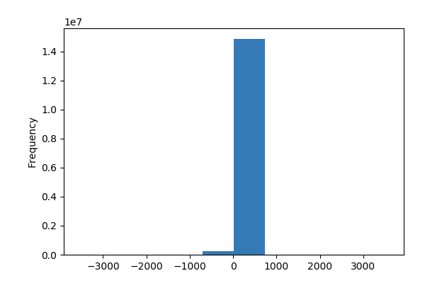

**Common Values**

| Value | Count | Frequency (%) |  |
| --- | --- | --- | --- |
| 0.0 | 259486 | 1.7% |  |
| 40.765991 | 7830 | 0.1% |  |
| 40.750156 | 1813 | 0.0% |  |
| 40.750183 | 1795 | 0.0% |  |
| 40.750107 | 1781 | 0.0% |  |
| 40.774319 | 1769 | 0.0% |  |
| 40.750141 | 1766 | 0.0% |  |
| 40.750172 | 1759 | 0.0% |  |
| 40.750118 | 1755 | 0.0% |  |
| 40.750126 | 1755 | 0.0% |  |
| Other values (89680) | 14820117 | 98.1% |  |

**Extreme Values**

Minimum 5 values

| Value | Count | Frequency (%) |  |
| --- | --- | --- | --- |
| -3547.8977 | 1 | 0.0% |  |
| -3517.926 | 1 | 0.0% |  |
| -3447.929 | 1 | 0.0% |  |
| -3447.9143 | 1 | 0.0% |  |
| -3281.1018 | 1 | 0.0% |  |

Maximum 5 values

| Value | Count | Frequency (%) |  |
| --- | --- | --- | --- |
| 3210.3591 | 1 | 0.0% |  |
| 3210.3689 | 1 | 0.0% |  |
| 3210.4028 | 1 | 0.0% |  |
| 3547.1287 | 1 | 0.0% |  |
| 3577.1265 | 1 | 0.0% |  |

dropoff_longitude  
Highly correlated

*This variable is highly correlated with `pickup_longitude` and should be ignored for analysis*

| Correlation | 0.90623 |
| --- | --- |

fare_amount  
Numeric

| Distinct count | 1461 |
| --- | --- |
| Unique (%) | 0.0% |
| Missing (%) | 0.0% |
| Missing (n) | 0 |
| Infinite (%) | 0.0% |
| Infinite (n) | 0 |

| Mean | 12.275 |
| --- | --- |
| Minimum | 2.5 |
| Maximum | 500 |
| Zeros (%) | 0.0% |

Toggle details

**Statistics**

Quantile statistics

| Minimum | 2.5 |
| --- | --- |
| 5-th percentile | 4.5 |
| Q1 | 6.5 |
| Median | 9.5 |
| Q3 | 14 |
| 95-th percentile | 31.5 |
| Maximum | 500 |
| Range | 497.5 |
| Interquartile range | 7.5 |

Descriptive statistics

| Standard deviation | 9.9621 |
| --- | --- |
| Coef of variation | 0.81156 |
| Kurtosis | 37.876 |
| Mean | 12.275 |
| MAD | 6.375 |
| Skewness | 3.727 |
| Sum | 185380000 |
| Variance | 99.244 |
| Memory size | 230.4 MiB |

**Histogram**

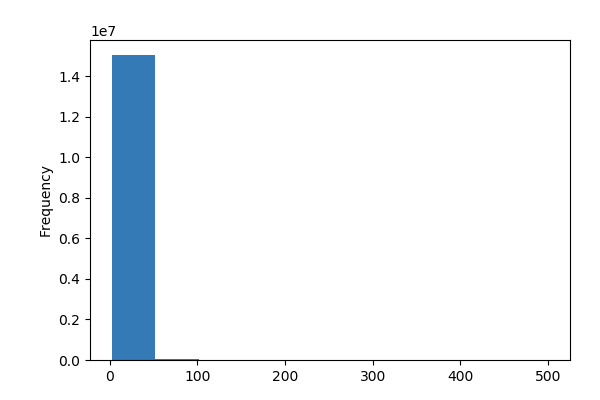

**Common Values**

| Value | Count | Frequency (%) |  |
| --- | --- | --- | --- |
| 6.5 | 762141 | 5.0% |  |
| 6.0 | 754966 | 5.0% |  |
| 7.0 | 745179 | 4.9% |  |
| 5.5 | 728420 | 4.8% |  |
| 7.5 | 724822 | 4.8% |  |
| 8.0 | 692794 | 4.6% |  |
| 5.0 | 657402 | 4.4% |  |
| 8.5 | 655533 | 4.3% |  |
| 9.0 | 609185 | 4.0% |  |
| 9.5 | 566357 | 3.8% |  |
| Other values (1451) | 8204973 | 54.3% |  |

**Extreme Values**

Minimum 5 values

| Value | Count | Frequency (%) |  |
| --- | --- | --- | --- |
| 2.5 | 52564 | 0.3% |  |
| 2.6 | 13 | 0.0% |  |
| 2.7 | 8 | 0.0% |  |
| 2.8 | 7 | 0.0% |  |
| 2.85 | 1 | 0.0% |  |

Maximum 5 values

| Value | Count | Frequency (%) |  |
| --- | --- | --- | --- |
| 480.0 | 1 | 0.0% |  |
| 490.0 | 2 | 0.0% |  |
| 493.85 | 1 | 0.0% |  |
| 495.0 | 1 | 0.0% |  |
| 500.0 | 9 | 0.0% |  |

hack_license  
Categorical

| Distinct count | 33111 |
| --- | --- |
| Unique (%) | 0.2% |
| Missing (%) | 0.0% |
| Missing (n) | 0 |

| D85749E8852FCC66A990E40605607B2F | 1612 |
| --- | --- |
| 51C1BE97280A80EBFA8DAD34E1956CF6 | 1600 |
| 3D757E111C78F5CAC83D44A92885D490 | 1508 |
| Other values (33108) | 15097052 |

Toggle details

| Value | Count | Frequency (%) |  |
| --- | --- | --- | --- |
| D85749E8852FCC66A990E40605607B2F | 1612 | 0.0% |  |
| 51C1BE97280A80EBFA8DAD34E1956CF6 | 1600 | 0.0% |  |
| 3D757E111C78F5CAC83D44A92885D490 | 1508 | 0.0% |  |
| 5FBB8BB5329B9E865727E4777F8CE91F | 1449 | 0.0% |  |
| 3AAB94CA53FE93A64811F65690654649 | 1411 | 0.0% |  |
| 23DF80C977D15141F11DD713C523C311 | 1405 | 0.0% |  |
| 98D89396A2CFD1C01333E245139473C0 | 1399 | 0.0% |  |
| 847349F8845A667D9AC7CDEDD1C873CB | 1387 | 0.0% |  |
| 9E035DBF346FDE01FE87FAB470276DA6 | 1354 | 0.0% |  |
| 44F3FA98ECDE0CB68787B2A8C2BAE4D0 | 1345 | 0.0% |  |
| Other values (33101) | 15087302 | 99.9% |  |

medallion  
Categorical

| Distinct count | 13464 |
| --- | --- |
| Unique (%) | 0.1% |
| Missing (%) | 0.0% |
| Missing (n) | 0 |

| 19E063791B0DF5A558B8488180DDAB67 | 2098 |
| --- | --- |
| 20BA941F62CC07F1FA3EF3E122B1E9B2 | 2035 |
| 75EE5A7E8B24FD2B2FB715955834C524 | 1993 |
| Other values (13461) | 15095646 |

Toggle details

| Value | Count | Frequency (%) |  |
| --- | --- | --- | --- |
| 19E063791B0DF5A558B8488180DDAB67 | 2098 | 0.0% |  |
| 20BA941F62CC07F1FA3EF3E122B1E9B2 | 2035 | 0.0% |  |
| 75EE5A7E8B24FD2B2FB715955834C524 | 1993 | 0.0% |  |
| 0C9C589C0AD57ECCB633CB90A33DC37A | 1988 | 0.0% |  |
| 9F1FEF916240E64AD4EC5B7883E6A435 | 1962 | 0.0% |  |
| 8253316266A5CA3EFF66163574D9A0B3 | 1938 | 0.0% |  |
| 99B1FD019B175E0CC6E57BC9E4FAAC94 | 1936 | 0.0% |  |
| 5BFFF6A2745737CEFE829A85167CA6C6 | 1934 | 0.0% |  |
| 7B1635AADDB360C9C664FE3A900BEF22 | 1922 | 0.0% |  |
| 863B16C717F37CE86D60435ACEEB0E2D | 1911 | 0.0% |  |
| Other values (13454) | 15082055 | 99.9% |  |

mta_tax  
Boolean

| Distinct count | 2 |
| --- | --- |
| Unique (%) | 0.0% |
| Missing (%) | 0.0% |
| Missing (n) | 0 |

| Mean | 0.49832 |
| --- | --- |

| 0.5 | 15050960 |
| --- | --- |
| 0.0 | 50812 |

Toggle details

| Value | Count | Frequency (%) |  |
| --- | --- | --- | --- |
| 0.5 | 15050960 | 99.7% |  |
| 0.0 | 50812 | 0.3% |  |

passenger_count  
Numeric

| Distinct count | 9 |
| --- | --- |
| Unique (%) | 0.0% |
| Missing (%) | 0.0% |
| Missing (n) | 0 |
| Infinite (%) | 0.0% |
| Infinite (n) | 0 |

| Mean | 1.709 |
| --- | --- |
| Minimum | 0 |
| Maximum | 9 |
| Zeros (%) | 0.0% |

Toggle details

**Statistics**

Quantile statistics

| Minimum | 0 |
| --- | --- |
| 5-th percentile | 1 |
| Q1 | 1 |
| Median | 1 |
| Q3 | 2 |
| 95-th percentile | 5 |
| Maximum | 9 |
| Range | 9 |
| Interquartile range | 1 |

Descriptive statistics

| Standard deviation | 1.3856 |
| --- | --- |
| Coef of variation | 0.81077 |
| Kurtosis | 2.8137 |
| Mean | 1.709 |
| MAD | 1.0055 |
| Skewness | 2.0162 |
| Sum | 25809472 |
| Variance | 1.92 |
| Memory size | 230.4 MiB |

**Histogram**

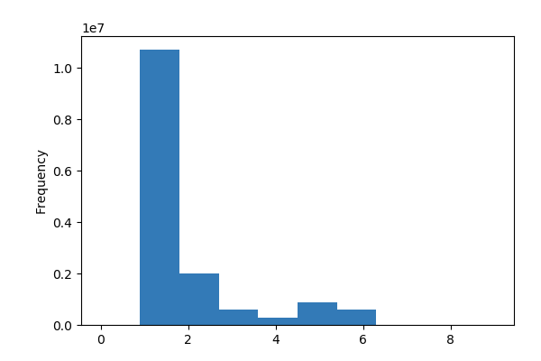

**Common Values**

| Value | Count | Frequency (%) |  |
| --- | --- | --- | --- |
| 1 | 10707975 | 70.9% |  |
| 2 | 1985916 | 13.2% |  |
| 5 | 890196 | 5.9% |  |
| 3 | 609900 | 4.0% |  |
| 6 | 609376 | 4.0% |  |
| 4 | 298178 | 2.0% |  |
| 0 | 229 | 0.0% |  |
| 9 | 1 | 0.0% |  |
| 8 | 1 | 0.0% |  |

**Extreme Values**

Minimum 5 values

| Value | Count | Frequency (%) |  |
| --- | --- | --- | --- |
| 0 | 229 | 0.0% |  |
| 1 | 10707975 | 70.9% |  |
| 2 | 1985916 | 13.2% |  |
| 3 | 609900 | 4.0% |  |
| 4 | 298178 | 2.0% |  |

Maximum 5 values

| Value | Count | Frequency (%) |  |
| --- | --- | --- | --- |
| 4 | 298178 | 2.0% |  |
| 5 | 890196 | 5.9% |  |
| 6 | 609376 | 4.0% |  |
| 8 | 1 | 0.0% |  |
| 9 | 1 | 0.0% |  |

payment_type  
Categorical

| Distinct count | 5 |
| --- | --- |
| Unique (%) | 0.0% |
| Missing (%) | 0.0% |
| Missing (n) | 0 |

| CRD | 8105838 |
| --- | --- |
| CSH | 6944575 |
| NOC | 33615 |
| Other values (2) | 17744 |

Toggle details

| Value | Count | Frequency (%) |  |
| --- | --- | --- | --- |
| CRD | 8105838 | 53.7% |  |
| CSH | 6944575 | 46.0% |  |
| NOC | 33615 | 0.2% |  |
| DIS | 11562 | 0.1% |  |
| UNK | 6182 | 0.0% |  |

pickup_datetime  
Categorical

| Distinct count | 2212633 |
| --- | --- |
| Unique (%) | 14.7% |
| Missing (%) | 0.0% |
| Missing (n) | 0 |

| 2013-04-19 22:41:00 | 439 |
| --- | --- |
| 2013-04-20 23:16:00 | 422 |
| 2013-04-19 22:44:00 | 419 |
| Other values (2212630) | 15100492 |

Toggle details

| Value | Count | Frequency (%) |  |
| --- | --- | --- | --- |
| 2013-04-19 22:41:00 | 439 | 0.0% |  |
| 2013-04-20 23:16:00 | 422 | 0.0% |  |
| 2013-04-19 22:44:00 | 419 | 0.0% |  |
| 2013-04-26 19:30:00 | 419 | 0.0% |  |
| 2013-04-20 22:33:00 | 419 | 0.0% |  |
| 2013-04-26 19:26:00 | 418 | 0.0% |  |
| 2013-04-19 22:43:00 | 413 | 0.0% |  |
| 2013-04-19 22:40:00 | 412 | 0.0% |  |
| 2013-04-20 23:27:00 | 410 | 0.0% |  |
| 2013-04-19 22:45:00 | 410 | 0.0% |  |
| Other values (2212623) | 15097591 | 100.0% |  |

pickup_latitude  
Numeric

| Distinct count | 64562 |
| --- | --- |
| Unique (%) | 0.4% |
| Missing (%) | 0.0% |
| Missing (n) | 0 |
| Infinite (%) | 0.0% |
| Infinite (n) | 0 |

| Mean | 40.068 |
| --- | --- |
| Minimum | -3481.1 |
| Maximum | 3210.4 |
| Zeros (%) | 1.7% |

Toggle details

**Statistics**

Quantile statistics

| Minimum | -3481.1 |
| --- | --- |
| 5-th percentile | 40.703 |
| Q1 | 40.735 |
| Median | 40.753 |
| Q3 | 40.768 |
| 95-th percentile | 40.788 |
| Maximum | 3210.4 |
| Range | 6691.5 |
| Interquartile range | 0.032417 |

Descriptive statistics

| Standard deviation | 6.9594 |
| --- | --- |
| Coef of variation | 0.17369 |
| Kurtosis | 82037 |
| Mean | 40.068 |
| MAD | 1.3482 |
| Skewness | -129.12 |
| Sum | 605090000 |
| Variance | 48.434 |
| Memory size | 230.4 MiB |

**Histogram**

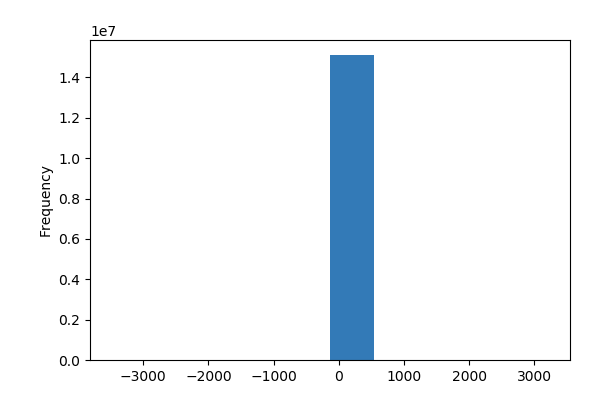

**Common Values**

| Value | Count | Frequency (%) |  |
| --- | --- | --- | --- |
| 0.0 | 251009 | 1.7% |  |
| 40.765991 | 7800 | 0.1% |  |
| 40.774094 | 2735 | 0.0% |  |
| 40.774078 | 2704 | 0.0% |  |
| 40.774117 | 2692 | 0.0% |  |
| 40.774101 | 2682 | 0.0% |  |
| 40.774109 | 2609 | 0.0% |  |
| 40.774063 | 2560 | 0.0% |  |
| 40.774071 | 2520 | 0.0% |  |
| 40.774052000000005 | 2476 | 0.0% |  |
| Other values (64552) | 14821985 | 98.1% |  |

**Extreme Values**

Minimum 5 values

| Value | Count | Frequency (%) |  |
| --- | --- | --- | --- |
| -3481.1411 | 1 | 0.0% |  |
| -3119.4922 | 1 | 0.0% |  |
| -3117.5542 | 1 | 0.0% |  |
| -3117.5227 | 1 | 0.0% |  |
| -3117.5105 | 1 | 0.0% |  |

Maximum 5 values

| Value | Count | Frequency (%) |  |
| --- | --- | --- | --- |
| 2321.5325 | 1 | 0.0% |  |
| 3010.1677 | 1 | 0.0% |  |
| 3210.3831 | 1 | 0.0% |  |
| 3210.3845 | 1 | 0.0% |  |
| 3210.3926 | 1 | 0.0% |  |

pickup_longitude  
Numeric

| Distinct count | 38931 |
| --- | --- |
| Unique (%) | 0.3% |
| Missing (%) | 0.0% |
| Missing (n) | 0 |
| Infinite (%) | 0.0% |
| Infinite (n) | 0 |

| Mean | -72.732 |
| --- | --- |
| Minimum | -2323.4 |
| Maximum | 2228.7 |
| Zeros (%) | 1.7% |

Toggle details

**Statistics**

Quantile statistics

| Minimum | -2323.4 |
| --- | --- |
| 5-th percentile | -74.007 |
| Q1 | -73.992 |
| Median | -73.982 |
| Q3 | -73.967 |
| 95-th percentile | -73.873 |
| Maximum | 2228.7 |
| Range | 4552.1 |
| Interquartile range | 0.025367 |

Descriptive statistics

| Standard deviation | 9.7383 |
| --- | --- |
| Coef of variation | -0.13389 |
| Kurtosis | 1661.5 |
| Mean | -72.732 |
| MAD | 2.4486 |
| Skewness | 1.5612 |
| Sum | -1098400000 |
| Variance | 94.834 |
| Memory size | 230.4 MiB |

**Histogram**

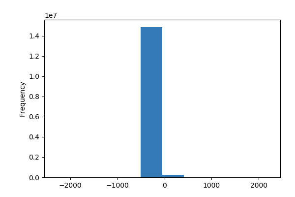

**Common Values**

| Value | Count | Frequency (%) |  |
| --- | --- | --- | --- |
| 0.0 | 253330 | 1.7% |  |
| -74.023048 | 6860 | 0.0% |  |
| -73.982208 | 5693 | 0.0% |  |
| -73.982239 | 5628 | 0.0% |  |
| -73.982224 | 5575 | 0.0% |  |
| -73.982079 | 5464 | 0.0% |  |
| -73.982285 | 5286 | 0.0% |  |
| -73.982201 | 5175 | 0.0% |  |
| -73.98233 | 5151 | 0.0% |  |
| -73.98236800000001 | 5143 | 0.0% |  |
| Other values (38921) | 14798467 | 98.0% |  |

**Extreme Values**

Minimum 5 values

| Value | Count | Frequency (%) |  |
| --- | --- | --- | --- |
| -2323.4202 | 1 | 0.0% |  |
| -2238.9929 | 1 | 0.0% |  |
| -2207.9519 | 1 | 0.0% |  |
| -2135.0703 | 1 | 0.0% |  |
| -2122.9985 | 1 | 0.0% |  |

Maximum 5 values

| Value | Count | Frequency (%) |  |
| --- | --- | --- | --- |
| 73.937775 | 4 | 0.0% |  |
| 100.98785 | 1 | 0.0% |  |
| 1328.7225 | 1 | 0.0% |  |
| 1498.7406 | 1 | 0.0% |  |
| 2228.7222 | 1 | 0.0% |  |

rate_code  
Numeric

| Distinct count | 15 |
| --- | --- |
| Unique (%) | 0.0% |
| Missing (%) | 0.0% |
| Missing (n) | 0 |
| Infinite (%) | 0.0% |
| Infinite (n) | 0 |

| Mean | 1.0333 |
| --- | --- |
| Minimum | 0 |
| Maximum | 210 |
| Zeros (%) | 0.0% |

Toggle details

**Statistics**

Quantile statistics

| Minimum | 0 |
| --- | --- |
| 5-th percentile | 1 |
| Q1 | 1 |
| Median | 1 |
| Q3 | 1 |
| 95-th percentile | 1 |
| Maximum | 210 |
| Range | 210 |
| Interquartile range | 0 |

Descriptive statistics

| Standard deviation | 0.34522 |
| --- | --- |
| Coef of variation | 0.3341 |
| Kurtosis | 141610 |
| Mean | 1.0333 |
| MAD | 0.065268 |
| Skewness | 240.51 |
| Sum | 15604475 |
| Variance | 0.11917 |
| Memory size | 230.4 MiB |

**Histogram**

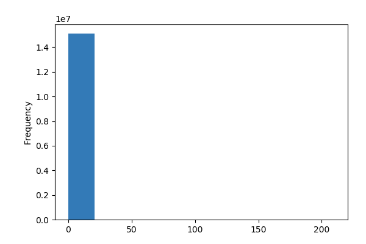

**Common Values**

| Value | Count | Frequency (%) |  |
| --- | --- | --- | --- |
| 1 | 14769577 | 97.8% |  |
| 2 | 255131 | 1.7% |  |
| 5 | 39140 | 0.3% |  |
| 3 | 22011 | 0.1% |  |
| 4 | 14580 | 0.1% |  |
| 0 | 1145 | 0.0% |  |
| 6 | 165 | 0.0% |  |
| 210 | 14 | 0.0% |  |
| 65 | 2 | 0.0% |  |
| 8 | 2 | 0.0% |  |
| Other values (5) | 5 | 0.0% |  |

**Extreme Values**

Minimum 5 values

| Value | Count | Frequency (%) |  |
| --- | --- | --- | --- |
| 0 | 1145 | 0.0% |  |
| 1 | 14769577 | 97.8% |  |
| 2 | 255131 | 1.7% |  |
| 3 | 22011 | 0.1% |  |
| 4 | 14580 | 0.1% |  |

Maximum 5 values

| Value | Count | Frequency (%) |  |
| --- | --- | --- | --- |
| 65 | 2 | 0.0% |  |
| 77 | 1 | 0.0% |  |
| 206 | 1 | 0.0% |  |
| 208 | 1 | 0.0% |  |
| 210 | 14 | 0.0% |  |

store_and_fwd_flag  
Categorical

| Distinct count | 3 |
| --- | --- |
| Unique (%) | 0.0% |
| Missing (%) | 49.8% |
| Missing (n) | 7519711 |

| N | 7452091 |
| --- | --- |
| Y | 129970 |
| (Missing) | 7519711 |

Toggle details

| Value | Count | Frequency (%) |  |
| --- | --- | --- | --- |
| N | 7452091 | 49.3% |  |
| Y | 129970 | 0.9% |  |
| (Missing) | 7519711 | 49.8% |  |

surcharge  
Numeric

| Distinct count | 22 |
| --- | --- |
| Unique (%) | 0.0% |
| Missing (%) | 0.0% |
| Missing (n) | 0 |
| Infinite (%) | 0.0% |
| Infinite (n) | 0 |

| Mean | 0.32668 |
| --- | --- |
| Minimum | 0 |
| Maximum | 15 |
| Zeros (%) | 50.3% |

Toggle details

**Statistics**

Quantile statistics

| Minimum | 0 |
| --- | --- |
| 5-th percentile | 0 |
| Q1 | 0 |
| Median | 0 |
| Q3 | 0.5 |
| 95-th percentile | 1 |
| Maximum | 15 |
| Range | 15 |
| Interquartile range | 0.5 |

Descriptive statistics

| Standard deviation | 0.36731 |
| --- | --- |
| Coef of variation | 1.1244 |
| Kurtosis | -0.66203 |
| Mean | 0.32668 |
| MAD | 0.32874 |
| Skewness | 0.65401 |
| Sum | 4933400 |
| Variance | 0.13492 |
| Memory size | 230.4 MiB |

**Histogram**

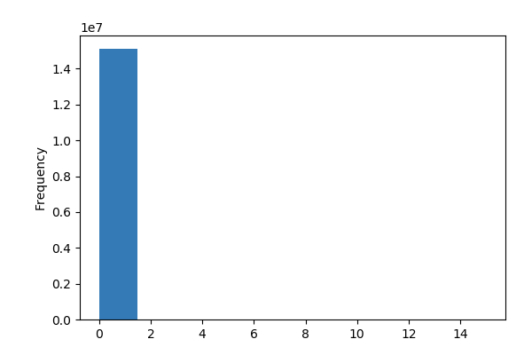

**Common Values**

| Value | Count | Frequency (%) |  |
| --- | --- | --- | --- |
| 0.0 | 7598450 | 50.3% |  |
| 0.5 | 5140110 | 34.0% |  |
| 1.0 | 2363054 | 15.6% |  |
| 1.5 | 104 | 0.0% |  |
| 2.0 | 17 | 0.0% |  |
| 2.5 | 11 | 0.0% |  |
| 6.0 | 3 | 0.0% |  |
| 1.23 | 3 | 0.0% |  |
| 4.0 | 3 | 0.0% |  |
| 4.5 | 2 | 0.0% |  |
| Other values (12) | 15 | 0.0% |  |

**Extreme Values**

Minimum 5 values

| Value | Count | Frequency (%) |  |
| --- | --- | --- | --- |
| 0.0 | 7598450 | 50.3% |  |
| 0.01 | 1 | 0.0% |  |
| 0.04 | 1 | 0.0% |  |
| 0.2 | 1 | 0.0% |  |
| 0.5 | 5140110 | 34.0% |  |

Maximum 5 values

| Value | Count | Frequency (%) |  |
| --- | --- | --- | --- |
| 6.0 | 3 | 0.0% |  |
| 8.0 | 1 | 0.0% |  |
| 8.5 | 1 | 0.0% |  |
| 9.0 | 1 | 0.0% |  |
| 15.0 | 1 | 0.0% |  |

tip_amount  
Numeric

| Distinct count | 3017 |
| --- | --- |
| Unique (%) | 0.0% |
| Missing (%) | 0.0% |
| Missing (n) | 0 |
| Infinite (%) | 0.0% |
| Infinite (n) | 0 |

| Mean | 1.3457 |
| --- | --- |
| Minimum | 0 |
| Maximum | 200 |
| Zeros (%) | 47.8% |

Toggle details

**Statistics**

Quantile statistics

| Minimum | 0 |
| --- | --- |
| 5-th percentile | 0 |
| Q1 | 0 |
| Median | 1 |
| Q3 | 2 |
| 95-th percentile | 5 |
| Maximum | 200 |
| Range | 200 |
| Interquartile range | 2 |

Descriptive statistics

| Standard deviation | 2.1322 |
| --- | --- |
| Coef of variation | 1.5845 |
| Kurtosis | 146.76 |
| Mean | 1.3457 |
| MAD | 1.3807 |
| Skewness | 5.6473 |
| Sum | 20323000 |
| Variance | 4.5464 |
| Memory size | 230.4 MiB |

**Histogram**

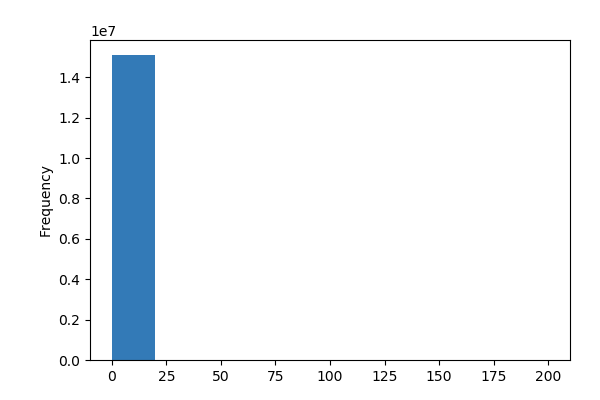

**Common Values**

| Value | Count | Frequency (%) |  |
| --- | --- | --- | --- |
| 0.0 | 7220943 | 47.8% |  |
| 1.0 | 1366865 | 9.1% |  |
| 2.0 | 746524 | 4.9% |  |
| 1.5 | 594986 | 3.9% |  |
| 3.0 | 255348 | 1.7% |  |
| 2.5 | 209659 | 1.4% |  |
| 1.8 | 186466 | 1.2% |  |
| 1.6 | 174721 | 1.2% |  |
| 1.4 | 172515 | 1.1% |  |
| 1.7 | 166910 | 1.1% |  |
| Other values (3007) | 4006835 | 26.5% |  |

**Extreme Values**

Minimum 5 values

| Value | Count | Frequency (%) |  |
| --- | --- | --- | --- |
| 0.0 | 7220943 | 47.8% |  |
| 0.01 | 3797 | 0.0% |  |
| 0.02 | 1230 | 0.0% |  |
| 0.03 | 449 | 0.0% |  |
| 0.04 | 220 | 0.0% |  |

Maximum 5 values

| Value | Count | Frequency (%) |  |
| --- | --- | --- | --- |
| 180.0 | 3 | 0.0% |  |
| 188.25 | 1 | 0.0% |  |
| 197.0 | 1 | 0.0% |  |
| 198.0 | 1 | 0.0% |  |
| 200.0 | 2 | 0.0% |  |

tolls_amount  
Numeric

| Distinct count | 597 |
| --- | --- |
| Unique (%) | 0.0% |
| Missing (%) | 0.0% |
| Missing (n) | 0 |
| Infinite (%) | 0.0% |
| Infinite (n) | 0 |

| Mean | 0.24473 |
| --- | --- |
| Minimum | 0 |
| Maximum | 20 |
| Zeros (%) | 95.6% |

Toggle details

**Statistics**

Quantile statistics

| Minimum | 0 |
| --- | --- |
| 5-th percentile | 0 |
| Q1 | 0 |
| Median | 0 |
| Q3 | 0 |
| 95-th percentile | 0 |
| Maximum | 20 |
| Range | 20 |
| Interquartile range | 0 |

Descriptive statistics

| Standard deviation | 1.1862 |
| --- | --- |
| Coef of variation | 4.847 |
| Kurtosis | 33.644 |
| Mean | 0.24473 |
| MAD | 0.4681 |
| Skewness | 5.3298 |
| Sum | 3695900 |
| Variance | 1.4071 |
| Memory size | 230.4 MiB |

**Histogram**

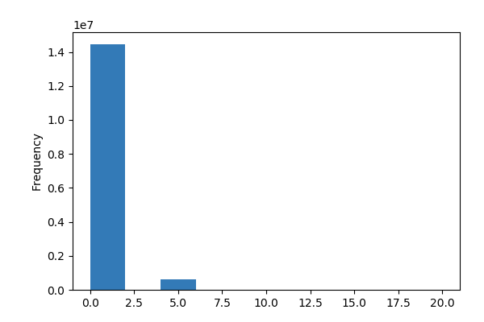

**Common Values**

| Value | Count | Frequency (%) |  |
| --- | --- | --- | --- |
| 0.0 | 14442673 | 95.6% |  |
| 5.33 | 610752 | 4.0% |  |
| 10.25 | 14499 | 0.1% |  |
| 2.44 | 6280 | 0.0% |  |
| 8.25 | 5653 | 0.0% |  |
| 10.66 | 3481 | 0.0% |  |
| 4.8 | 3476 | 0.0% |  |
| 7.5 | 1168 | 0.0% |  |
| 15.58 | 1085 | 0.0% |  |
| 15.99 | 1044 | 0.0% |  |
| Other values (587) | 11661 | 0.1% |  |

**Extreme Values**

Minimum 5 values

| Value | Count | Frequency (%) |  |
| --- | --- | --- | --- |
| 0.0 | 14442673 | 95.6% |  |
| 0.01 | 54 | 0.0% |  |
| 0.02 | 5 | 0.0% |  |
| 0.03 | 4 | 0.0% |  |
| 0.04 | 22 | 0.0% |  |

Maximum 5 values

| Value | Count | Frequency (%) |  |
| --- | --- | --- | --- |
| 19.8 | 3 | 0.0% |  |
| 19.88 | 2 | 0.0% |  |
| 19.91 | 1 | 0.0% |  |
| 19.98 | 1 | 0.0% |  |
| 20.0 | 66 | 0.0% |  |

total_amount  
Highly correlated

*This variable is highly correlated with `fare_amount` and should be ignored for analysis*

| Correlation | 0.98334 |
| --- | --- |

trip_distance  
Numeric

| Distinct count | 4243 |
| --- | --- |
| Unique (%) | 0.0% |
| Missing (%) | 0.0% |
| Missing (n) | 0 |
| Infinite (%) | 0.0% |
| Infinite (n) | 0 |

| Mean | 2.8631 |
| --- | --- |
| Minimum | 0 |
| Maximum | 100 |
| Zeros (%) | 0.7% |

Toggle details

**Statistics**

Quantile statistics

| Minimum | 0 |
| --- | --- |
| 5-th percentile | 0.5 |
| Q1 | 1.04 |
| Median | 1.78 |
| Q3 | 3.2 |
| 95-th percentile | 9.7 |
| Maximum | 100 |
| Range | 100 |
| Interquartile range | 2.16 |

Descriptive statistics

| Standard deviation | 3.3449 |
| --- | --- |
| Coef of variation | 1.1683 |
| Kurtosis | 16.063 |
| Mean | 2.8631 |
| MAD | 2.0886 |
| Skewness | 3.2699 |
| Sum | 43238000 |
| Variance | 11.188 |
| Memory size | 230.4 MiB |

**Histogram**

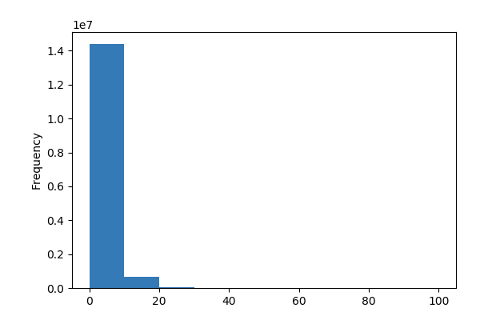

**Common Values**

| Value | Count | Frequency (%) |  |
| --- | --- | --- | --- |
| 1.0 | 343279 | 2.3% |  |
| 0.9 | 341647 | 2.3% |  |
| 0.8 | 333553 | 2.2% |  |
| 1.1 | 332311 | 2.2% |  |
| 1.2 | 320042 | 2.1% |  |
| 0.7 | 309319 | 2.0% |  |
| 1.3 | 304910 | 2.0% |  |
| 1.4 | 290884 | 1.9% |  |
| 1.5 | 275146 | 1.8% |  |
| 0.6 | 267291 | 1.8% |  |
| Other values (4233) | 11983390 | 79.4% |  |

**Extreme Values**

Minimum 5 values

| Value | Count | Frequency (%) |  |
| --- | --- | --- | --- |
| 0.0 | 112666 | 0.7% |  |
| 0.01 | 3393 | 0.0% |  |
| 0.02 | 2769 | 0.0% |  |
| 0.03 | 2755 | 0.0% |  |
| 0.04 | 2845 | 0.0% |  |

Maximum 5 values

| Value | Count | Frequency (%) |  |
| --- | --- | --- | --- |
| 95.4 | 1 | 0.0% |  |
| 95.9 | 1 | 0.0% |  |
| 96.0 | 1 | 0.0% |  |
| 96.8 | 1 | 0.0% |  |
| 100.0 | 8 | 0.0% |  |

trip_time_in_secs  
Numeric

| Distinct count | 6314 |
| --- | --- |
| Unique (%) | 0.0% |
| Missing (%) | 0.0% |
| Missing (n) | 0 |
| Infinite (%) | 0.0% |
| Infinite (n) | 0 |

| Mean | 746.61 |
| --- | --- |
| Minimum | 0 |
| Maximum | 10800 |
| Zeros (%) | 0.3% |

Toggle details

**Statistics**

Quantile statistics

| Minimum | 0 |
| --- | --- |
| 5-th percentile | 180 |
| Q1 | 360 |
| Median | 600 |
| Q3 | 960 |
| 95-th percentile | 1787 |
| Maximum | 10800 |
| Range | 10800 |
| Interquartile range | 600 |

Descriptive statistics

| Standard deviation | 550.51 |
| --- | --- |
| Coef of variation | 0.73735 |
| Kurtosis | 8.8224 |
| Mean | 746.61 |
| MAD | 396.64 |
| Skewness | 2.16 |
| Sum | 11275074505 |
| Variance | 303060 |
| Memory size | 230.4 MiB |

**Histogram**

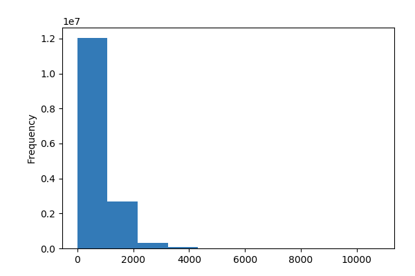

**Common Values**

| Value | Count | Frequency (%) |  |
| --- | --- | --- | --- |
| 360 | 510407 | 3.4% |  |
| 420 | 508293 | 3.4% |  |
| 480 | 493809 | 3.3% |  |
| 300 | 488517 | 3.2% |  |
| 540 | 467565 | 3.1% |  |
| 600 | 434640 | 2.9% |  |
| 240 | 428511 | 2.8% |  |
| 660 | 398303 | 2.6% |  |
| 720 | 361004 | 2.4% |  |
| 780 | 325950 | 2.2% |  |
| Other values (6304) | 10684773 | 70.8% |  |

**Extreme Values**

Minimum 5 values

| Value | Count | Frequency (%) |  |
| --- | --- | --- | --- |
| 0 | 38688 | 0.3% |  |
| 1 | 1241 | 0.0% |  |
| 2 | 2889 | 0.0% |  |
| 3 | 2263 | 0.0% |  |
| 4 | 2068 | 0.0% |  |

Maximum 5 values

| Value | Count | Frequency (%) |  |
| --- | --- | --- | --- |
| 10620 | 1 | 0.0% |  |
| 10680 | 2 | 0.0% |  |
| 10713 | 1 | 0.0% |  |
| 10740 | 1 | 0.0% |  |
| 10800 | 2 | 0.0% |  |

vendor_id_x  
Categorical

| Distinct count | 2 |
| --- | --- |
| Unique (%) | 0.0% |
| Missing (%) | 0.0% |
| Missing (n) | 0 |

| CMT | 7582775 |
| --- | --- |
| VTS | 7518997 |

Toggle details

| Value | Count | Frequency (%) |  |
| --- | --- | --- | --- |
| CMT | 7582775 | 50.2% |  |
| VTS | 7518997 | 49.8% |  |

vendor_id_y  
Categorical

| Distinct count | 2 |
| --- | --- |
| Unique (%) | 0.0% |
| Missing (%) | 0.0% |
| Missing (n) | 0 |

| CMT | 7582775 |
| --- | --- |
| VTS | 7518997 |

Toggle details

| Value | Count | Frequency (%) |  |
| --- | --- | --- | --- |
| CMT | 7582775 | 50.2% |  |
| VTS | 7518997 | 49.8% |  |

Correlations

Sample

|  | medallion | hack_license | vendor_id_x | rate_code | store_and_fwd_flag | pickup_datetime | dropoff_datetime | passenger_count | trip_time_in_secs | trip_distance | pickup_longitude | pickup_latitude | dropoff_longitude | dropoff_latitude | vendor_id_y | payment_type | fare_amount | surcharge | mta_tax | tip_amount | tolls_amount | total_amount |
| --- | --- | --- | --- | --- | --- | --- | --- | --- | --- | --- | --- | --- | --- | --- | --- | --- | --- | --- | --- | --- | --- | --- |
| 0 | 91F6EB84975BBC867E32CB113C7C2CD5 | AD8751110E6292079EB10EB9481FE1A6 | CMT | 1 | N | 2013-04-04 18:47:45 | 2013-04-04 19:00:25 | 1 | 759 | 2.5 | -73.957855 | 40.765320 | -73.976273 | 40.785648 | CMT | CRD | 11.0 | 1.0 | 0.5 | 2.50 | 0.0 | 15.00 |
| 1 | EC34CD1B3797DFAFF3FE099BA87B6656 | 8FE6A4AEDF89B6B4E19D2377FD3FB7D7 | CMT | 1 | N | 2013-04-05 07:08:34 | 2013-04-05 07:17:34 | 1 | 540 | 1.6 | 0.000000 | 0.000000 | 0.000000 | 0.000000 | CMT | CRD | 8.5 | 0.0 | 0.5 | 1.80 | 0.0 | 10.80 |
| 2 | C1B9DA774DC2BBC6DE27CE994E7F44A0 | E1B595FD55E4C82C1E213EB17438107A | CMT | 1 | N | 2013-04-04 17:59:50 | 2013-04-04 18:21:48 | 1 | 1318 | 3.6 | -73.982880 | 40.754990 | -74.009186 | 40.715374 | CMT | CRD | 16.5 | 1.0 | 0.5 | 3.60 | 0.0 | 21.60 |
| 3 | 9BA84250355AB3FC031C9252D395BF8A | 16BB0D96A0DCC853AEC7F55C8D6C71E0 | CMT | 1 | N | 2013-04-04 18:12:01 | 2013-04-04 18:25:24 | 1 | 799 | 1.9 | -73.978119 | 40.763451 | -73.955666 | 40.776642 | CMT | CRD | 10.0 | 1.0 | 0.5 | 3.45 | 0.0 | 14.95 |
| 4 | 205A696DF62AD03C88DA8C5EC5248639 | 579C41EA5EC846F8B641A42F9EE3E855 | CMT | 1 | N | 2013-04-04 20:12:57 | 2013-04-04 20:29:55 | 1 | 1017 | 3.6 | -74.006371 | 40.744755 | -73.961662 | 40.761082 | CMT | CRD | 15.0 | 0.5 | 0.5 | 3.20 | 0.0 | 19.20 |

```python
pandas_profiling.ProfileReport(trip)
```

### Data Cleaning : Removing trip records that are possibly captured wrongly due to hardware/software/human errors

```
- 1) Reject Overly Correlated Columns: Fare Amount/Total Amount  | dropoff_longitude/pickup_longitude  ???
- 2) Handling Overly Skewed columns : dropoff_latitude / pickup_latitude / rate_code  (REMOVE ERRONEOUS RECORDS)
- 3) Handling Columns with Highly Missing values: store_and_fwd_flag (REMOVE AS COLUMN IS ALMOST USELESS)
- 4) Handling Columns with missing values: If it's a few, just drop, if not impute accordingly
- 5) Removing duplicates
- 6) Remove other values that don't make sense
```

#### Removal of Duplicate Records

```python
# print(trip.duplicated().sum())
print(trip.drop_duplicates(keep='first',inplace=True))
```

```
None
```

#### Check for and handle Null Values

- Drop 146 trip records from missing dropoff latitude & longtitude columns as they appear to be an error resulting from hardware/software failure : No trip time / distance / store_and_fwd_flag / passenger count etc.

```python
print(trip.isnull().sum())
```

[output not shown]

```python
trip[trip.dropoff_longitude.isna()]
```

|  | medallion | hack_license | vendor_id | rate_code | store_and_fwd_flag | pickup_datetime | dropoff_datetime | passenger_count | trip_time_in_secs | trip_distance | ... | pickup_latitude | dropoff_longitude | dropoff_latitude | payment_type | fare_amount | surcharge | mta_tax | tip_amount | tolls_amount | total_amount |
| --- | --- | --- | --- | --- | --- | --- | --- | --- | --- | --- | --- | --- | --- | --- | --- | --- | --- | --- | --- | --- | --- |
| 2719639 | 45C115E61799037F6C1CB45A6D1538AC | 783FA9E59430C5B73A0E629A5032D957 | CMT | 0 | NaN | 2013-04-29 06:09:00 | 2013-04-29 08:09:00 | 0 | 0 | 0.0 | ... | 40.782314 | NaN | NaN | CRD | 30.50 | 0.0 | 0.5 | 5.00 | 5.33 | 41.33 |
| 2788269 | 03B354861CC944EEBBDFCC6B205B54BA | 53EC0370395F1403B28FD9E2597E4A7F | CMT | 0 | NaN | 2013-04-30 03:35:11 | 2013-04-30 09:35:11 | 0 | 0 | 0.0 | ... | 40.759262 | NaN | NaN | CRD | 40.00 | 0.5 | 0.5 | 13.89 | 5.33 | 60.22 |
| 3317976 | 19282FDE07F6A1696C1CCA45206069F1 | 0A3688387D4FEB9D10E173D0D55EC829 | CMT | 0 | NaN | 2013-04-12 15:46:38 | 2013-04-12 15:59:27 | 0 | 0 | 0.0 | ... | 40.744213 | NaN | NaN | CRD | 11.40 | 0.0 | 0.0 | 0.00 | 0.00 | 11.40 |
| 3324424 | 22D1934CF861B8BE43F10FBAD93FEF69 | C08B5251D128450F7ECE3D54D441971C | CMT | 0 | NaN | 2013-04-14 21:12:16 | 2013-04-14 21:29:45 | 0 | 0 | 0.0 | ... | 40.750336 | NaN | NaN | CRD | 20.15 | 0.0 | 0.0 | 0.00 | 0.00 | 20.15 |
| 3324990 | AB42AE725E1A71D06940A0B6DDBD8D5C | AB1C267B12D4DC2E76DEEE412542DCC0 | CMT | 0 | NaN | 2013-04-14 21:46:44 | 2013-04-14 22:07:58 | 0 | 0 | 0.0 | ... | 40.759769 | NaN | NaN | CRD | 20.00 | 0.0 | 0.0 | 0.00 | 0.00 | 20.00 |
| 3374928 | AD1054F7E91A4FDF9964637617BC44EE | 269B6E49AA5A1E4E89DB7FF08D680722 | CMT | 0 | NaN | 2013-04-12 12:24:54 | 2013-04-12 13:02:43 | 0 | 0 | 0.0 | ... | 40.751396 | NaN | NaN | CRD | 34.20 | 0.0 | 0.0 | 0.00 | 0.00 | 34.20 |
| 3943420 | 9400FEF51A4DE705BD4578E3AB86A318 | 0870264E465139C732BEE2A3E420BA07 | CMT | 0 | NaN | 2013-04-12 12:52:53 | 2013-04-12 13:02:19 | 0 | 0 | 0.0 | ... | 40.739643 | NaN | NaN | CRD | 10.50 | 0.0 | 0.0 | 0.00 | 0.00 | 10.50 |
| 4918135 | 7F82F9083BCBA10112AB131656AB3D37 | EC48BE55AB74CE34EEF44D49C4F9EA5B | CMT | 0 | NaN | 2013-04-12 19:27:03 | 2013-04-12 19:32:56 | 0 | 0 | 0.0 | ... | 40.759636 | NaN | NaN | CRD | 9.75 | 0.0 | 0.0 | 0.00 | 0.00 | 9.75 |
| 5420831 | C1DF399EA2F262B432834349F4A8DE65 | 783832AFA60404D80FA92C4CFA379FF9 | CMT | 0 | NaN | 2013-04-14 19:54:00 | 2013-04-14 19:59:39 | 0 | 0 | 0.0 | ... | 40.759380 | NaN | NaN | CRD | 9.00 | 0.0 | 0.0 | 0.00 | 0.00 | 9.00 |
| 5448060 | 68DA326C672DDB24B0886218C0541A8B | 2CADA416808E1568D7CFB5BA45D7984D | CMT | 0 | NaN | 2013-04-14 05:40:25 | 2013-04-14 05:57:42 | 0 | 0 | 0.0 | ... | 40.776100 | NaN | NaN | CRD | 22.80 | 0.0 | 0.0 | 0.00 | 0.00 | 22.80 |
| 5469728 | CF55516DF007804BE3998D921683C7B6 | A978E00491FEF62927C2C598477D3E2D | CMT | 0 | NaN | 2013-04-14 21:48:52 | 2013-04-14 22:02:00 | 0 | 0 | 0.0 | ... | 40.734932 | NaN | NaN | CRD | 15.60 | 0.0 | 0.0 | 0.00 | 0.00 | 15.60 |
| 5476299 | E2736817DA1FC6BD862BF69F3C5CDF7D | A6CD1457C979A3DD21DE4C883F663757 | CMT | 0 | NaN | 2013-04-14 21:52:33 | 2013-04-14 22:04:53 | 0 | 0 | 0.0 | ... | 40.730354 | NaN | NaN | CRD | 12.50 | 0.0 | 0.0 | 0.00 | 0.00 | 12.50 |
| 5490968 | 1DB26B77B7E1F92921D52EB3C2FB278B | 17517E1FF07054B50523A1FA200F9D70 | CMT | 0 | NaN | 2013-04-14 22:03:47 | 2013-04-14 22:42:37 | 0 | 0 | 0.0 | ... | 40.645172 | NaN | NaN | CRD | 69.38 | 0.0 | 0.0 | 0.00 | 0.00 | 69.38 |
| 5497053 | DACFA6EF35923081481A22BE96339B6E | 8CD28EB8CF78958162D04C0B50A7DCE9 | CMT | 0 | NaN | 2013-04-14 05:48:04 | 2013-04-14 05:57:19 | 0 | 0 | 0.0 | ... | 40.739880 | NaN | NaN | CRD | 11.50 | 0.0 | 0.0 | 0.00 | 0.00 | 11.50 |
| 5525163 | D15B1BE447F4ACA7BFF0ECAE9A9C0B04 | EB2D906AF4D3366652B002AA497B8EA1 | CMT | 0 | NaN | 2013-04-14 22:40:11 | 2013-04-14 22:45:34 | 0 | 0 | 0.0 | ... | 40.752666 | NaN | NaN | CRD | 7.15 | 0.0 | 0.0 | 0.00 | 0.00 | 7.15 |
| 5534835 | 4B9649B4861D085E6E61527980F0D26A | 7BE61909A3DDCCF3C38873A44A326625 | CMT | 0 | NaN | 2013-04-02 20:05:26 | 2013-04-02 20:11:07 | 0 | 0 | 0.0 | ... | 40.754723 | NaN | NaN | CRD | 6.00 | 0.0 | 0.0 | 0.00 | 0.00 | 6.00 |
| 5540654 | BB335F5E8F26D6909F86BD00F1CECB33 | 368EC90CBD15B8B3F7628F72CFA94ED4 | CMT | 0 | NaN | 2013-04-14 01:18:17 | 2013-04-14 01:30:24 | 0 | 0 | 0.0 | ... | 40.760521 | NaN | NaN | CRD | 12.50 | 0.0 | 0.0 | 0.00 | 0.00 | 12.50 |
| 5545880 | 231C251B25DC34F23AEA0BDF96E25C0E | 94A8F8ADB3DD859D4489C5EC5079DDDE | CMT | 0 | NaN | 2013-04-14 22:10:51 | 2013-04-14 22:27:36 | 0 | 0 | 0.0 | ... | 40.775425 | NaN | NaN | CRD | 27.00 | 0.0 | 0.0 | 0.00 | 0.00 | 27.00 |
| 5556510 | 2A4681196DB5419EB816DFE971E070A5 | AD01E7EA9918D77989C036CC98AF1B3B | CMT | 0 | NaN | 2013-04-14 05:47:20 | 2013-04-14 05:57:24 | 0 | 0 | 0.0 | ... | 40.758274 | NaN | NaN | CRD | 13.80 | 0.0 | 0.0 | 0.00 | 0.00 | 13.80 |
| 5717716 | C92B03F37589E0232CFA683D64AE61BE | FC5B87A9F359670DD9E6CCB37854995B | CMT | 0 | NaN | 2013-04-14 21:57:18 | 2013-04-14 22:08:49 | 0 | 0 | 0.0 | ... | 40.722252 | NaN | NaN | CRD | 12.50 | 0.0 | 0.0 | 0.00 | 0.00 | 12.50 |
| 5722812 | B76308C0FC5D776DA2EFFC4BC67E421F | CB1134B177AC0D0400403CD7B4929694 | CMT | 0 | NaN | 2013-04-14 05:49:36 | 2013-04-14 05:57:56 | 0 | 0 | 0.0 | ... | 40.790291 | NaN | NaN | CRD | 12.00 | 0.0 | 0.0 | 0.00 | 0.00 | 12.00 |
| 5784542 | 7D99C30FCE69B1A9DD27E2AEAC9BFA0C | 460C3F57DD9CB2265DB75B14CD70224D | CMT | 0 | NaN | 2013-04-01 20:39:32 | 2013-04-01 21:01:27 | 0 | 0 | 0.0 | ... | 40.749451 | NaN | NaN | CRD | 31.00 | 0.0 | 0.0 | 0.00 | 0.00 | 31.00 |
| 5828475 | C65B8987D740DA46AFFBE3A475AF85BE | 7895E8BDFDB5AE3C913D9AFEF756B75E | CMT | 0 | NaN | 2013-04-01 20:47:09 | 2013-04-01 21:00:43 | 0 | 0 | 0.0 | ... | 40.723591 | NaN | NaN | CRD | 15.60 | 0.0 | 0.0 | 0.00 | 0.00 | 15.60 |
| 5841912 | 42183FEBABC165712D6E9339A081D972 | 645E094CE36A05C174CE3CA8DEC3175E | CMT | 0 | NaN | 2013-04-14 21:24:35 | 2013-04-14 21:34:03 | 0 | 0 | 0.0 | ... | 40.759155 | NaN | NaN | CRD | 12.50 | 0.0 | 0.0 | 0.00 | 0.00 | 12.50 |
| 5842125 | 2C6CA43E0FAAC32375DDA0BDDC948A91 | E17D417ECE51FD94BBE9E5926A363A50 | CMT | 0 | NaN | 2013-04-14 21:26:00 | 2013-04-14 21:34:04 | 0 | 0 | 0.0 | ... | 40.724823 | NaN | NaN | CRD | 10.20 | 0.0 | 0.0 | 0.00 | 0.00 | 10.20 |
| 5855093 | 2843F5D7F2BAC3B24C0F6929392F9384 | 8A5E7D159DCC9E5E857A71A7029463D4 | CMT | 0 | NaN | 2013-04-01 20:09:00 | 2013-04-01 21:01:06 | 0 | 0 | 0.0 | ... | 40.726723 | NaN | NaN | CRD | 12.50 | 0.0 | 0.0 | 0.00 | 0.00 | 12.50 |
| 5877422 | E2592DA19DD99FEB2E1A3EDA98A0F36D | 1E242FE94709DE84CED8759C549820DD | CMT | 0 | NaN | 2013-04-03 07:26:41 | 2013-04-03 07:34:35 | 0 | 0 | 0.0 | ... | 40.784248 | NaN | NaN | CRD | 11.50 | 0.0 | 0.0 | 0.00 | 0.00 | 11.50 |
| 5901630 | E20B8C6AF036C084CBB40EAB0BF1DB04 | E7750A37CAB07D0DFF0AF7E3573AC141 | CMT | 0 | NaN | 2013-04-01 20:53:52 | 2013-04-01 21:01:26 | 0 | 0 | 0.0 | ... | 40.749420 | NaN | NaN | CRD | 9.50 | 0.0 | 0.0 | 0.00 | 0.00 | 9.50 |
| 5928937 | DED4170ED1EB2C4DD59AD353F4ECD8F6 | 26E360A3257DFA700C6359FD5F1A6869 | CMT | 0 | NaN | 2013-04-06 00:28:29 | 2013-04-06 00:42:41 | 0 | 0 | 0.0 | ... | 40.765282 | NaN | NaN | CRD | 15.00 | 0.0 | 0.0 | 0.00 | 0.00 | 15.00 |
| 5941195 | CFF1FDD049E5433E6FBCC96EDA9E66A5 | 1B1F76CCF7BBC79BA438AB0C69235B06 | CMT | 0 | NaN | 2013-04-14 22:24:00 | 2013-04-14 22:39:13 | 0 | 0 | 0.0 | ... | 40.759022 | NaN | NaN | CRD | 21.00 | 0.0 | 0.0 | 0.00 | 0.00 | 21.00 |
| ... | ... | ... | ... | ... | ... | ... | ... | ... | ... | ... | ... | ... | ... | ... | ... | ... | ... | ... | ... | ... | ... |
| 7616597 | 0545C6C1D0CDD74064C4B99C962BC0FE | 53934B9562ED4D4F95F289283BCF8476 | CMT | 0 | NaN | 2013-04-14 22:24:22 | 2013-04-14 22:32:37 | 0 | 0 | 0.0 | ... | 40.763550 | NaN | NaN | CRD | 10.20 | 0.0 | 0.0 | 0.00 | 0.00 | 10.20 |
| 7617152 | 37E179EA8676577E99A374652E002E3A | 8D36B4B1338F03B29F00C607421A2029 | CMT | 0 | NaN | 2013-04-14 22:12:15 | 2013-04-14 22:35:58 | 0 | 0 | 0.0 | ... | 40.706844 | NaN | NaN | CRD | 28.10 | 0.0 | 0.0 | 0.00 | 0.00 | 28.10 |
| 7627764 | A38882246FC6439948FA470459F94134 | 8A60E3668580091A4BB124E9BDAFDD89 | CMT | 0 | NaN | 2013-04-14 21:01:36 | 2013-04-14 21:35:22 | 0 | 0 | 0.0 | ... | 40.644661 | NaN | NaN | CRD | 45.00 | 0.0 | 0.0 | 0.00 | 0.00 | 45.00 |
| 7639568 | B085C7CC04E3A80D137318997A8B494E | 0D78EFCBB36D2E27237A352CACF3CA20 | CMT | 0 | NaN | 2013-04-14 22:26:40 | 2013-04-14 22:30:53 | 0 | 0 | 0.0 | ... | 40.745686 | NaN | NaN | CRD | 7.80 | 0.0 | 0.0 | 0.00 | 0.00 | 7.80 |
| 7640580 | CB06D00120162467DDD4F525DCF4F6B4 | 36235B488EE048C49ACDA5F634EA8DF3 | CMT | 0 | NaN | 2013-04-14 22:02:37 | 2013-04-14 22:08:00 | 0 | 0 | 0.0 | ... | 40.750282 | NaN | NaN | CRD | 8.72 | 0.0 | 0.0 | 0.00 | 0.00 | 8.72 |
| 7663427 | 95B0E8E13FF920DC35841D766241FDEE | FF065737BE906972590C25D3B03F2FE0 | CMT | 0 | NaN | 2013-04-14 05:57:00 | 2013-04-14 05:57:52 | 0 | 0 | 0.0 | ... | 0.000000 | NaN | NaN | CRD | 63.83 | 0.0 | 0.0 | 0.00 | 0.00 | 63.83 |
| 7664709 | 25607A6415888129D72DAE6044C777CF | 4D4B44702EC36BBE864B8641084196B4 | CMT | 0 | NaN | 2013-04-14 19:56:15 | 2013-04-14 19:58:42 | 0 | 0 | 0.0 | ... | 40.737827 | NaN | NaN | CRD | 4.80 | 0.0 | 0.0 | 0.00 | 0.00 | 4.80 |
| 7671562 | 49FB4587B997C2BA236184F01C38E832 | 4F9784E016C2F0E4881C7ABD8FAE9D3A | CMT | 0 | NaN | 2013-04-14 22:23:15 | 2013-04-14 22:27:49 | 0 | 0 | 0.0 | ... | 40.744663 | NaN | NaN | CRD | 7.50 | 0.0 | 0.0 | 0.00 | 0.00 | 7.50 |
| 7682899 | 25607A6415888129D72DAE6044C777CF | 4D4B44702EC36BBE864B8641084196B4 | CMT | 0 | NaN | 2013-04-14 22:18:24 | 2013-04-14 22:30:42 | 0 | 0 | 0.0 | ... | 40.747860 | NaN | NaN | CRD | 15.00 | 0.0 | 0.0 | 0.00 | 0.00 | 15.00 |
| 7697297 | 3740052A57B580D326CF3603A733FF85 | 3AE87D4A5B16647A01E90DF6D83A79DB | CMT | 0 | NaN | 2013-04-14 21:45:46 | 2013-04-14 22:05:21 | 0 | 0 | 0.0 | ... | 0.000000 | NaN | NaN | CRD | 25.00 | 0.0 | 0.0 | 0.00 | 0.00 | 25.00 |
| 7709142 | 9CAD586BE0A5E2172A7A343D73AD117C | 0A8C3EA91301974683245B6E65F56476 | CMT | 0 | NaN | 2013-04-02 20:51:49 | 2013-04-02 21:00:42 | 0 | 0 | 0.0 | ... | 40.733418 | NaN | NaN | CRD | 11.05 | 0.0 | 0.0 | 0.00 | 0.00 | 11.05 |
| 7741248 | AE5823D849CD24ED19AC5F77B55D4122 | 0D5414B8519FBCBF6966013E012D16A9 | CMT | 0 | NaN | 2013-04-02 20:18:07 | 2013-04-02 20:39:47 | 0 | 0 | 0.0 | ... | 40.750336 | NaN | NaN | CRD | 26.00 | 0.0 | 0.0 | 0.00 | 0.00 | 26.00 |
| 7779216 | 81D63C85750AF2C4D125380942446905 | 275247EE7A34F840BEDCDDF41A7E2E94 | CMT | 0 | NaN | 2013-04-14 21:54:51 | 2013-04-14 22:05:17 | 0 | 0 | 0.0 | ... | 40.679192 | NaN | NaN | CRD | 11.00 | 0.0 | 0.0 | 0.00 | 0.00 | 11.00 |
| 7788253 | C767E6FAAE6A65D77701979221AE61CF | 2A6A2823157A8F9B1054A5278B744F39 | CMT | 0 | NaN | 2013-04-14 05:30:44 | 2013-04-14 05:57:41 | 0 | 0 | 0.0 | ... | 40.767731 | NaN | NaN | CRD | 27.50 | 0.0 | 0.0 | 0.00 | 0.00 | 27.50 |
| 10695445 | A60B2798C4A181C8D5425F32C30E0BB9 | 23275210DBD53DBBAE68508B0186092F | CMT | 0 | NaN | 2013-04-06 20:51:54 | 2013-04-06 21:01:44 | 0 | 0 | 0.0 | ... | 40.733032 | NaN | NaN | CRD | 10.20 | 0.0 | 0.0 | 0.00 | 0.00 | 10.20 |
| 10764071 | C65B8987D740DA46AFFBE3A475AF85BE | 7553656E6D6276E6BFFBDB0D930B9DAF | CMT | 0 | NaN | 2013-04-07 20:30:31 | 2013-04-07 21:00:53 | 0 | 0 | 0.0 | ... | 40.713997 | NaN | NaN | CRD | 30.60 | 0.0 | 0.0 | 0.00 | 0.00 | 30.60 |
| 10799375 | D647D82A8DB7E741EFE115A29CA74322 | C59076A3CEF43D97F246292945E24512 | CMT | 0 | NaN | 2013-04-05 15:11:04 | 2013-04-05 16:33:44 | 0 | 0 | 0.0 | ... | 40.644634 | NaN | NaN | CRD | 116.16 | 0.0 | 0.0 | 0.00 | 0.00 | 116.16 |
| 10802784 | 4463A0F1490839D29FA9575E1A6391AC | 9ECE1C9F5AFD6C633A2097964431E545 | CMT | 0 | NaN | 2013-04-05 17:44:41 | 2013-04-05 18:05:00 | 0 | 0 | 0.0 | ... | 40.758163 | NaN | NaN | CRD | 18.12 | 0.0 | 0.0 | 0.00 | 0.00 | 18.12 |
| 10836855 | 9A468A5F1C1ECA0549DD0FB4083102C5 | D13EE7AE5E00C4493B75EDA31641C258 | CMT | 0 | NaN | 2013-04-07 16:35:31 | 2013-04-07 16:48:10 | 0 | 0 | 0.0 | ... | 40.759289 | NaN | NaN | CRD | 12.50 | 0.0 | 0.0 | 0.00 | 0.00 | 12.50 |
| 10854705 | 145B43B78FFD64614601831FC7AB2114 | 1B604CA74E6CEE6BE0FDE53CF2AB6406 | CMT | 0 | NaN | 2013-04-06 20:30:00 | 2013-04-06 21:01:12 | 0 | 0 | 0.0 | ... | 40.725075 | NaN | NaN | CRD | 24.00 | 0.0 | 0.0 | 0.00 | 0.00 | 24.00 |
| 10913740 | 5F6AFDC77A62E61DCDABAE404E2D2AA1 | FAE818D38BA85750EFC30565C158E8F1 | CMT | 0 | NaN | 2013-04-06 20:18:05 | 2013-04-06 21:01:28 | 0 | 0 | 0.0 | ... | 40.731827 | NaN | NaN | CRD | 30.00 | 0.0 | 0.0 | 0.00 | 0.00 | 30.00 |
| 10920631 | B6AA6EAFD523192F22D16B4033DA717F | 08026D69508127F4DE855678ABCE7E0A | CMT | 0 | NaN | 2013-04-07 20:57:00 | 2013-04-07 21:01:37 | 0 | 0 | 0.0 | ... | 40.724758 | NaN | NaN | CRD | 6.85 | 0.0 | 0.0 | 0.00 | 0.00 | 6.85 |
| 10922610 | 06EEA6240F616CCE31E5F33D901DAAB0 | A0C23FF9E69E6D5D9AF6D9C43B1F4E07 | CMT | 0 | NaN | 2013-04-01 20:48:58 | 2013-04-01 21:01:33 | 0 | 0 | 0.0 | ... | 40.728237 | NaN | NaN | CRD | 15.00 | 0.0 | 0.0 | 0.00 | 0.00 | 15.00 |
| 10928593 | D7479C954DF136B1545CBF8491361A8D | C99D1B7F4DEF6B7DC032F987695703F6 | CMT | 0 | NaN | 2013-04-07 20:49:00 | 2013-04-07 21:01:47 | 0 | 0 | 0.0 | ... | 40.738083 | NaN | NaN | CRD | 13.50 | 0.0 | 0.0 | 0.00 | 0.00 | 13.50 |
| 10949583 | B01A3E26873C4B5145DED29355E1CEFD | 8544DDB96863DF697A1BF599E278EF41 | CMT | 0 | NaN | 2013-04-07 20:44:13 | 2013-04-07 21:01:59 | 0 | 0 | 0.0 | ... | 40.745285 | NaN | NaN | CRD | 23.50 | 0.0 | 0.0 | 0.00 | 0.00 | 23.50 |
| 10953900 | 868EEA093554BEDF30E63192007CCE2F | 2D433B21AC8CB45CC6EBF776D8A830CA | CMT | 0 | NaN | 2013-04-07 20:50:06 | 2013-04-07 21:01:54 | 0 | 0 | 0.0 | ... | 40.719887 | NaN | NaN | CRD | 13.75 | 0.0 | 0.0 | 0.00 | 0.00 | 13.75 |
| 10971612 | 113D0572C45BFA1D44C96D25A5F7089F | ED94199D4F6978C71AE51C52BC847526 | CMT | 0 | NaN | 2013-04-07 13:47:32 | 2013-04-07 14:00:27 | 0 | 0 | 0.0 | ... | 40.729416 | NaN | NaN | CRD | 15.00 | 0.0 | 0.0 | 0.00 | 0.00 | 15.00 |
| 11891418 | BB24D772F7F29E567AF483AA831BC7F8 | 825583CB43AE3AFAD5235D74D642374E | CMT | 0 | NaN | 2013-04-14 19:33:27 | 2013-04-14 20:09:23 | 0 | 0 | 0.0 | ... | 40.740326 | NaN | NaN | CRD | 31.20 | 0.0 | 0.0 | 0.00 | 0.00 | 31.20 |
| 11913302 | 6D822F7E606A6C023796CCC20ED32F75 | 09D4443D76709D09E876DACF238BB42F | CMT | 0 | NaN | 2013-04-14 20:02:23 | 2013-04-14 20:12:30 | 0 | 0 | 0.0 | ... | 40.727222 | NaN | NaN | CRD | 12.00 | 0.0 | 0.0 | 0.00 | 0.00 | 12.00 |
| 11927030 | 713CFE265811AC6CDC452098F47D48F6 | FA7A7A5A581189747FF1AB83859E38AC | CMT | 0 | NaN | 2013-04-14 20:26:00 | 2013-04-14 20:48:04 | 0 | 0 | 0.0 | ... | 40.769871 | NaN | NaN | CRD | 43.53 | 0.0 | 0.0 | 0.00 | 0.00 | 43.53 |

146 rows × 21 columns

```python
trip.dropna(axis = 0, how ='any',subset=['dropoff_longitude','dropoff_latitude'],inplace=True)
```

#### Removal of Rate Codes >6

- Remove 23 trip records where Rate Code is > 6 (Invalid according to data dictionary)

```python
trip[trip.rate_code>6].rate_code.value_counts().sum()
```

```
23
```

```python
trip= trip[trip.rate_code<=6]
```

#### Removal of latitude and longitude values that lie beyond the sensible range of values

- According to google : Longitude is in the range -180 and +180 specifying coordinates west and east of the Prime Meridian, respectively. For reference, the Equator has a latitude of 0°, the North pole has a latitude of 90° north (written 90° N or +90°), and the South pole has a latitude of -90°.
- Also remove trips whose lat and long lie on the Greenwich Meridian (NOT IN NYC)

```python
trip = trip[(trip.pickup_latitude<=90) & (trip.pickup_latitude>=-90)
            & (trip.pickup_longitude<=180) & (trip.pickup_longitude>=-180)
            & (trip.dropoff_latitude<=90) & (trip.dropoff_latitude>=-90)
            & (trip.dropoff_longitude<=180) & (trip.dropoff_longitude>=-180)]

trip = trip[~((trip.pickup_latitude==0.000000) & (trip.pickup_longitude==0.000000))]
trip = trip[~((trip.dropoff_longitude==0.000000) & (trip.dropoff_latitude==0.000000))]
```

#### Removal of trip_duration values that are too low or too high to make sense¶

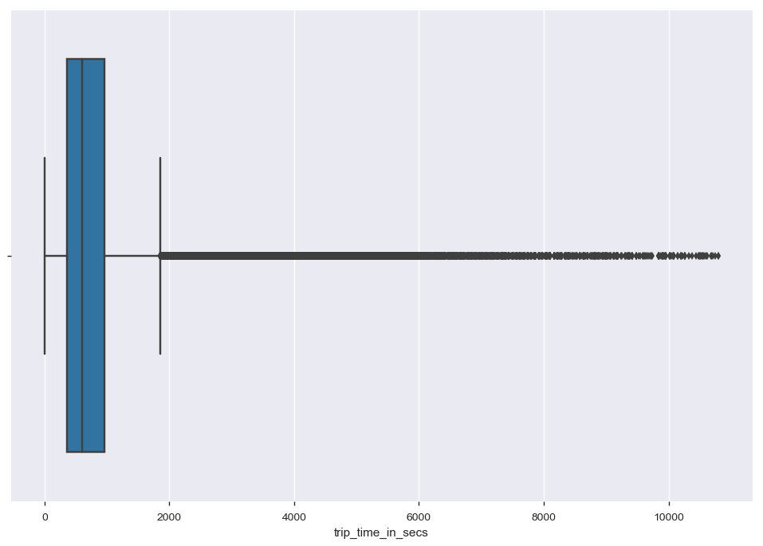

```python
plt.figure(figsize=(12,8))
sns.boxplot(x=trip.trip_time_in_secs)
```

```python
Q1 = trip.trip_time_in_secs.quantile(0.25)
Q3 = trip.trip_time_in_secs.quantile(0.75)
IQR = Q3 - Q1

print(trip[trip.trip_time_in_secs > (Q3 + 1.5 * IQR)].shape[0])
print(trip[trip.trip_time_in_secs > (Q3 + 1.5 * IQR)].shape[0]/ trip.shape[0])
print(trip[trip.trip_time_in_secs > (Q3 + 1.5 * IQR)].trip_time_in_secs.min())
print(trip[trip.trip_time_in_secs > (Q3 + 1.5 * IQR)].trip_time_in_secs.max())
```

```
632496
0.041883546449643407
1861
10800
```

```python
# Get names of indexes for which trip time in seconds <=0.0 and trip is not a negotiated fare
# indexNames = trip[(trip.trip_time_in_secs<=0.0) & (trip.rate_code!=5)].index
indexNames = trip[(trip.trip_time_in_secs<=0.0)].index

# Delete these row indexes from dataFrame
trip.drop(indexNames , inplace=True)

# Get names of indexes for which trip_time_in_secs >7200 (2 Hours)
indexNames = trip[(trip.trip_time_in_secs>7200)].index

# Delete these row indexes from dataFrame
trip.drop(indexNames , inplace=True)
```

#### Removal of trip_distance values that are too low or too high to make sense

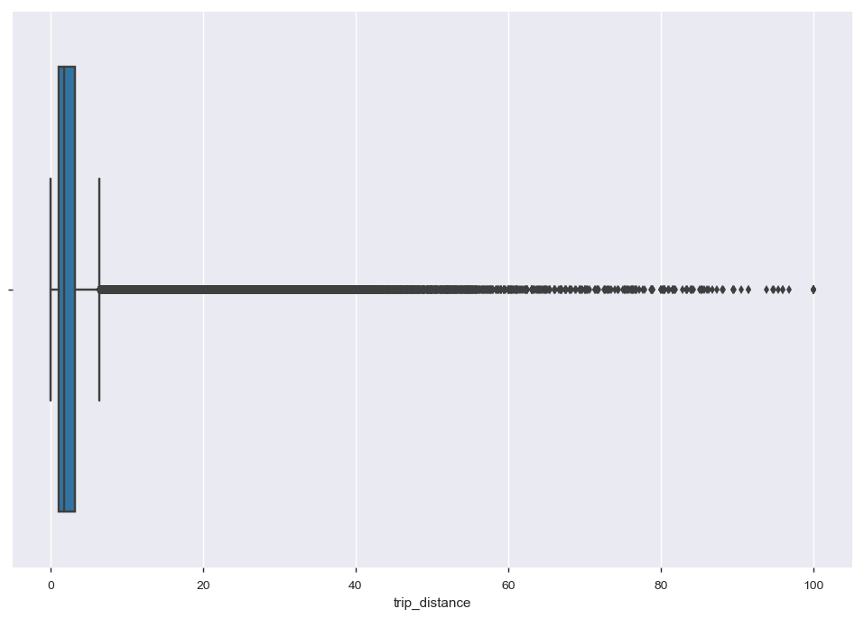

```python
plt.figure(figsize=(12,8))
sns.boxplot(x=trip.trip_distance)
```

```python
Q1 = trip.trip_distance.quantile(0.25)
Q3 = trip.trip_distance.quantile(0.75)
IQR = Q3 - Q1

print(trip[trip.trip_distance > (Q3 + 1.5 * IQR)].shape[0])
print(trip[trip.trip_distance > (Q3 + 1.5 * IQR)].shape[0]/ trip.shape[0])
print(trip[trip.trip_distance > (Q3 + 1.5 * IQR)].trip_distance.min())
print(trip[trip.trip_distance > (Q3 + 1.5 * IQR)].trip_distance.max())
```

```
1408928
0.09346867369002333
6.43
100.0
```

```python
# Get names of indexes for which trip distance <=0.0 and trip is not a negotiated fare
# indexNames = trip[(trip.trip_distance<=0.0) & (trip.rate_code!=5)].index
indexNames = trip[(trip.trip_distance<=0.0)].index

# Delete these row indexes from dataFrame
trip.drop(indexNames , inplace=True)


# Get names of indexes for which trip distance >=50 miles
indexNames = trip[(trip['trip_distance']>=50)].index

# Delete these row indexes from dataFrame
trip.drop(indexNames , inplace=True)
```

#### Removal of fare amounts that are below the base fare

- Check Base Fare (2013) -> Eliminate those below or equal to base fare if it exists ( NO NEED TO)
- Check for outliers and remove them during prediction

```python
trip.loc[trip['fare_amount']<0].shape
```

```
(0, 21)
```

### Total Records Removed after Cleaning :

```python
print("Total Records removed after cleaning data:  {}".format(15101772-trip.shape[0]))
```

```
Total Records removed after cleaning data:  360298
```

### Baseline Trip Data for building Initial Predictive Model (No Feature Engineering)

```python
trip_baseline = copy.deepcopy(trip)
```

```python
trip_baseline.to_csv('trip_baseline.csv',index=False)
```

### Generate Features for Exploratory Data Analysis

[output not shown]

#### Converting datetime variables to datetime objects

```python
trip.pickup_datetime = pd.to_datetime(trip.pickup_datetime)
trip.dropoff_datetime = pd.to_datetime(trip.dropoff_datetime)
```

### Generate Date Time Features :

- Day of week (7 days)
- Days in a month (31 days)
- Hours in a day (24 hours)
- Minutes in a day (24 * 60 minutes)
- *Months in a year not relevant as the data set is only for 1 month*

```python
# Datetime Breakdown for pickup and dropoff datetimes in Trip Dataset

trip['pickup_day_of_week']= trip.pickup_datetime.dt.dayofweek

trip['pickup_day_of_month']= trip.pickup_datetime.dt.day

trip['pickup_weekday_name']= trip.pickup_datetime.dt.weekday_name

trip['pickup_hour']= trip.pickup_datetime.dt.hour

# trip['pickup_minute']= trip.pickup_datetime.dt.minute


trip['dropoff_day_of_week']= trip.dropoff_datetime.dt.dayofweek

trip['dropoff _day_of_month']= trip.dropoff_datetime.dt.day

trip['dropoff _weekday_name']= trip.dropoff_datetime.dt.weekday_name

trip['dropoff _hour']= trip.dropoff_datetime.dt.hour

# trip['dropoff_minute']= trip.dropoff_datetime.dt.minute
```

### Generate Fare Amount Features :

- Fare per unit distance
- Fare per second

```python
trip['fare_amount_per_unit_distance']=trip.fare_amount/trip.trip_distance

trip['fare_amount_per_second']=trip.fare_amount/trip.trip_time_in_secs
```

### Generate Location Features :

###### *I would like to credit Aiswarya Ramachandran for this piece of code and providing the context behind the categorization of location into zones called boroughs. The content was originally obtained from here: https://medium.com/analytics-vidhya/machine-learning-to-predict-taxi-fare-part-one-exploratory-analysis-6b7e6b1fbc78*

```python
nyc_boroughs={
    'manhattan':{
        'min_lng':-74.0479,
        'min_lat':40.6829,
        'max_lng':-73.9067,
        'max_lat':40.8820
    },
    'queens':{
        'min_lng':-73.9630,
        'min_lat':40.5431,
        'max_lng':-73.7004,
        'max_lat':40.8007
    },

    'brooklyn':{
        'min_lng':-74.0421,
        'min_lat':40.5707,
        'max_lng':-73.8334,
        'max_lat':40.7395
    },

    'bronx':{
        'min_lng':-73.9339,
        'min_lat':40.7855,
        'max_lng':-73.7654,
        'max_lat':40.9176
    },
    'staten_island':{
        'min_lng':-74.2558,
        'min_lat':40.4960,
        'max_lng':-74.0522,
        'max_lat':40.6490
    }
}
```

```python
def getBorough(lat,lng):

    locs=nyc_boroughs.keys()
    for loc in locs:
        if lat>=nyc_boroughs[loc]['min_lat'] and lat<=nyc_boroughs[loc]['max_lat'] and lng>=nyc_boroughs[loc]['min_lng'] and lng<=nyc_boroughs[loc]['max_lng']:
            return loc
    return 'others'
```

```python
trip['pickup_borough']=trip.apply(lambda row:getBorough(row['pickup_latitude'],row['pickup_longitude']),axis=1)
trip['dropoff_borough']=trip.apply(lambda row:getBorough(row['dropoff_latitude'],row['dropoff_longitude']),axis=1)
```

### Export Data after New Features have been added

```python
trip.to_csv("trip_with_new_features.csv",index=False)
```

# PART A : Exploratory Data Analysis (Basic Questions + More)

### a) What are the top 5 busiest hours of the day?

```python
trips_per_hour = trip.groupby('pickup_hour').agg({'medallion':'count'}).reset_index().rename(columns={'medallion':'Num_Trips'})
```

```python
trips_per_hour.Num_Trips=trips_per_hour.Num_Trips/30
```

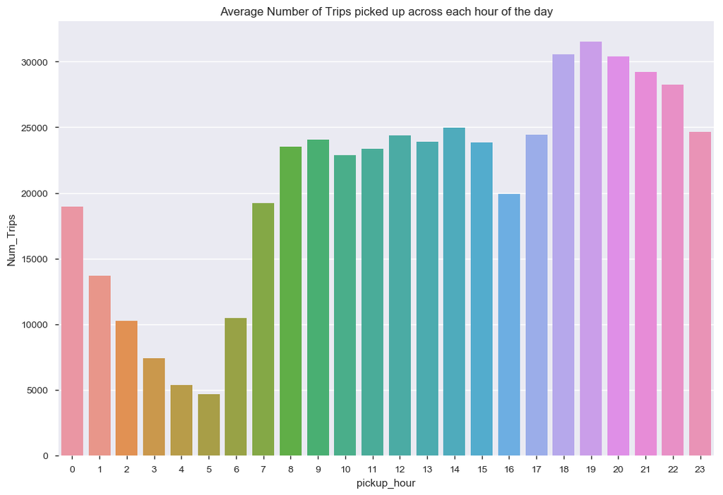

```python
# Busiest is defined by the number of pickups in an hour
plt.figure(figsize=(12,8))
sns.barplot(x="pickup_hour", y='Num_Trips',data=trips_per_hour).set_title("Average Number of Trips picked up across each hour of the day")
plt.show()
```

### b) What are the top 10 busiest locations of the city?

#### Distribution of Boroughs across April 2013 trips

```
Text(0.5,1,'Distribution of Pickup Boroughs')
```

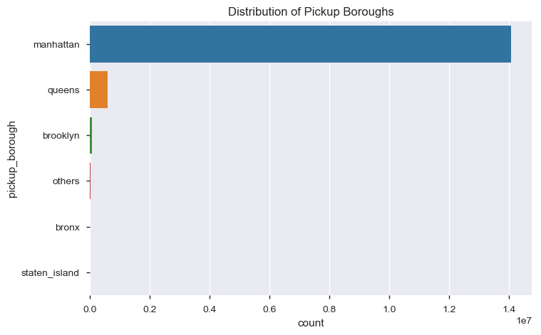

```python
plt.figure(figsize=(8,5))
sns.countplot(y=trip['pickup_borough'])
plt.title("Distribution of Pickup Boroughs")
```

```python
trip.columns=trip.columns.tolist()
```

```python
trip.groupby(['pickup_longitude','pickup_latitude','pickup_borough'])['vendor_id'].agg({'vendor_id':'count'}).reset_index().sort_values(by='vendor_id',ascending=False).head(15)
```

|  | pickup_longitude | pickup_latitude | pickup_borough | vendor_id |
| --- | --- | --- | --- | --- |
| 10979519 | 0.000000 | 0.000000 | others | 7275 |
| 7865 | -74.023048 | 40.765991 | manhattan | 6828 |
| 3038657 | -73.990944 | 40.736053 | manhattan | 848 |
| 10267069 | -73.949043 | 40.744915 | manhattan | 843 |
| 10648363 | -73.917358 | 40.670559 | queens | 391 |
| 10981026 | 0.000000 | 41.453693 | others | 250 |
| 10694308 | -73.883629 | 40.632210 | queens | 238 |
| 838 | -74.195213 | 40.548466 | staten_island | 155 |
| 10980314 | 0.000000 | 40.754341 | others | 145 |
| 8631614 | -73.965012 | 40.755657 | manhattan | 129 |
| 4428285 | -73.985542 | 40.722073 | manhattan | 92 |
| 9862420 | -73.954109 | 40.750622 | manhattan | 85 |
| 7499821 | -73.972855 | 40.724857 | manhattan | 80 |
| 10956003 | -73.781319 | 40.644886 | queens | 77 |
| 2866576 | -73.991608 | 40.736771 | manhattan | 75 |

```python
trip.groupby(['dropoff_longitude','dropoff_latitude']).agg({'vendor_id':'count'}).reset_index().sort_values(by='vendor_id',ascending=False).head(11)
```

|  | dropoff_longitude | dropoff_latitude | vendor_id |
| --- | --- | --- | --- |
| 12281086 | 0.000000 | 0.000000 | 258783 |
| 48385 | -74.023048 | 40.765991 | 7045 |
| 3177550 | -73.990944 | 40.736053 | 853 |
| 11053162 | -73.949043 | 40.744915 | 853 |
| 11810940 | -73.917358 | 40.670559 | 390 |
| 11981237 | -73.883629 | 40.632210 | 239 |
| 12282555 | 0.000000 | 41.453693 | 233 |
| 1861 | -74.195213 | 40.548466 | 157 |
| 12281865 | 0.000000 | 40.754341 | 150 |
| 9129034 | -73.965012 | 40.755657 | 129 |
| 4560392 | -73.985542 | 40.722073 | 91 |